# Sensor_02c_Aliasing

## Contents

- Illustrate sensor aliasing using a monochrome sensor
- Set up a sweep frequency
- We use a small pixel size and see the scene come through correctly
- Make the sensor pixel under-sample by creating a large pixel.
- Now, protect from aliasing by using a blurry lens
- This is what aliasing looks like for the slanted bar target
- If we protect against aliasing

## Illustrate sensor aliasing using a monochrome sensor

When the acuity of the lens exceeds the sampling rate of the sensor, aliasing patterns emerge. These are low frequency patterns in the sensor response that are caused by the high frequency patterns in the original image but under-sampled by the sensor.

To protect against aliasing, you can use a lens that does not pass the high frequency terms.

The aliasing artifacts illustrated here are for a monochrome sensor. When the same problem arises from a color CFA, the artifacts emerge as unwanted colors (chromatic aliasing).

Copyright Imageval Consulting, LLC, 2016

```matlab
ieInit
```

## Set up a sweep frequency

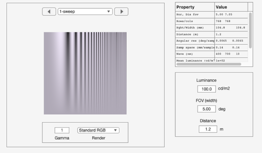

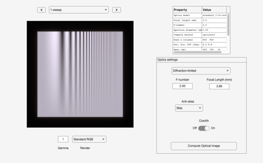

```matlab
fov = 5;
scene = sceneCreate('sweep frequency',768,30);
scene = sceneSet(scene,'fov',fov);
ieAddObject(scene); sceneWindow;

% Set up a high acuity lens
oi = oiCreate('diffraction limited');
oi = oiSet(oi,'optics fnumber', 2);
oi = oiCompute(oi,scene);
ieAddObject(oi); oiWindow;
```

## We use a small pixel size and see the scene come through correctly

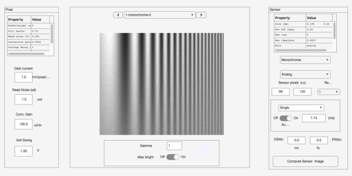

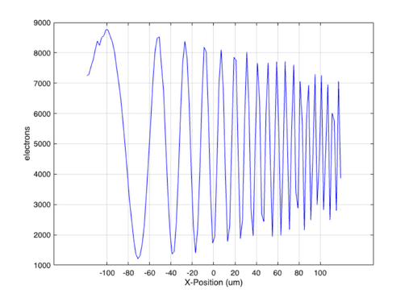

```matlab
sensor = sensorCreate('monochrome');
sensor = sensorSetSizeToFOV(sensor,fov,oi);

% Set a two micron pixel
sensor = sensorSet(sensor,'pixel size constant fill factor',2e-6);
sensor = sensorCompute(sensor,oi);
ieAddObject(sensor);
sensorWindow;

sensorPlot(sensor,'electrons hline',[5 1]);
```

## Make the sensor pixel under-sample by creating a large pixel.

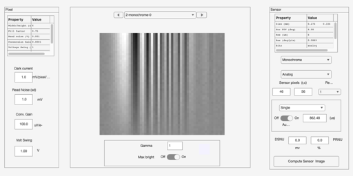

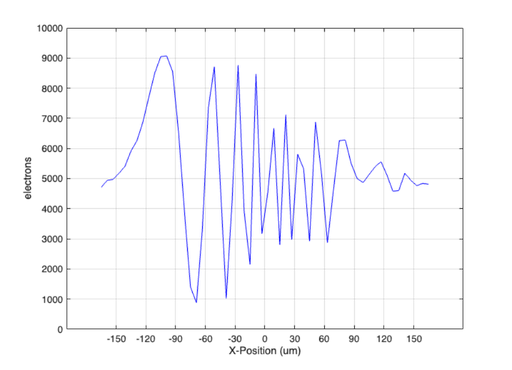

```matlab
% Now, notice the aliased signal on the right.  The scene and oi are high
% spatial frequency, but the sensor capture appears to be low spatial
% frequency.
sensor = sensorSet(sensor,'pixel size constant fill factor',6e-6);
sensor = sensorSetSizeToFOV(sensor,fov,oi);
sensor = sensorCompute(sensor,oi);
ieAddObject(sensor); sensorWindow;

sensorPlot(sensor,'electrons hline',[5 1]);
```

## Now, protect from aliasing by using a blurry lens

```
ans =

  struct with fields:

     pixPos: [-165.0000 -159.0000 -153.0000 -147.0000 -141 … ] (1×56 double)
    pixData: [4587 5135 5126 5292 5571 6219 6707 7207 8058 … ] (1×56 double)
```

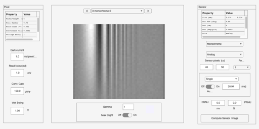

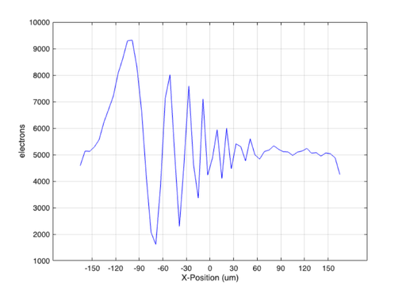

```matlab
oi = oiSet(oi,'optics fnumber', 12);
oi = oiCompute(oi,scene);
sensor = sensorCompute(sensor,oi);
ieAddObject(sensor); sensorWindow;

sensorPlot(sensor,'electrons hline',[5 1])
```

## This is what aliasing looks like for the slanted bar target

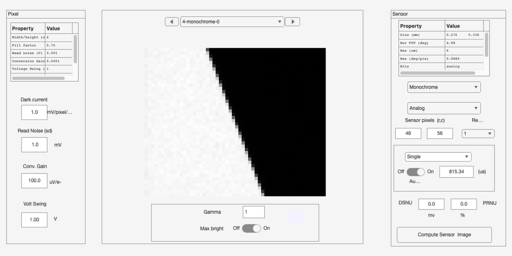

```matlab
% This is why people sometimes say 'aliasing' creates 'jaggies'
scene = sceneCreate('slanted bar',1024);
scene = sceneSet(scene,'fov',fov);

oi = oiSet(oi,'optics fnumber', 2);
sensor = sensorSet(sensor,'pixel size constant fill factor',6e-6);
sensor = sensorSetSizeToFOV(sensor,fov,oi);
oi = oiCompute(oi,scene);
sensor = sensorCompute(sensor,oi);
ieAddObject(sensor); sensorWindow;
```

## If we protect against aliasing

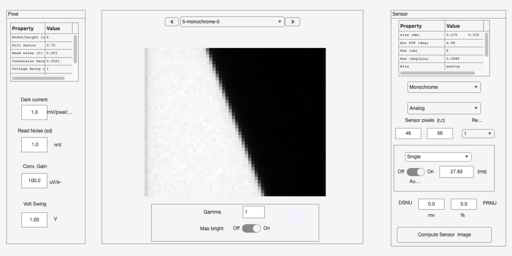

```matlab
oi = oiSet(oi,'optics fnumber', 12);
oi = oiCompute(oi,scene);
sensor = sensorCompute(sensor,oi);
ieAddObject(sensor); sensorWindow;
```

[Published with MATLAB® R2025b](https://www.mathworks.com/products/matlab/)